# Pre-processing of image-based compound pheno-signatures

Steffen Jaensch

06 April 2017

```r
source('PhenoPrint/MasterThesis2017/stools.R') # normalization and convenience functions
```

# Load aggregated data

This data has been created by aggregating the single-cell data per well, taking the mean of each feature.

```r
datadir <- 'C:/sjaensch/docu/HCS projects/2014-09 ITS Proposal -- PhenoPrinting/MasterThesis 2017/data'


# fn_in_means     <- 'p1602xxPPS_means.Rdata'
# fn_in_wellinfo  <- 'p1602xxPPS_wellInfo_forExternalUse.csv'
# fn_out          <- 'p1602xxPPS_means_preprocessed.Rdata'

fn_in_means     <- 'p1601xxPPS_means.Rdata'
fn_in_wellinfo  <- 'p1601xxPPS_wellInfo_forExternalUse.csv'
fn_out          <- 'p1601xxPPS_means_preprocessed.Rdata'

fn_in_means     <- file.path(datadir, fn_in_means)
fn_in_wellinfo  <- file.path(datadir, fn_in_wellinfo)
fn_out          <- file.path(datadir, fn_out)

load(fn_in_means) # ==> dw
```

```r
sort(table(dw$PLATE_ID))
```

```
##
## 67070 67071 67072 67199 67200 67201 67268 67269 67270 67073 67074 67075
##   264   264   264   264   264   264   264   264   264   308   308   308
## 67076 67077 67078 67079 67080 67081 67082 67083 67084 67085 67086 67087
##   308   308   308   308   308   308   308   308   308   308   308   308
## 67202 67203 67204 67205 67206 67207 67208 67209 67210 67211 67212 67213
##   308   308   308   308   308   308   308   308   308   308   308   308
## 67214 67215 67216 67271 67272 67273 67274 67275 67276 67277 67278 67280
##   308   308   308   308   308   308   308   308   308   308   308   308
## 67281 67282 67283 67288 67289 67306
##   308   308   308   308   308   308
```

# Add plate layout (compound, concentration, …)

The plate layout has been extracted from data from the PhenoPrint workflow. It contains only valid wells, in particular fluorescent compounds are already removed. When joining the well data with the plate layout, the wells not present in the plate layout will therefore automatically be dropped.

```r
winfo <- read.csv(fn_in_wellinfo, as.is = TRUE)
cat(paste0(sort(names(winfo)),collapse = ', '))
```

```
## BARCODE, cellLine, CMPD_ID, COL_NR, CONCENTRATION, EXPERIMENT_ID, expID, is_fluorescent, PLATE_ID, ROW_NR, Treatment, WELL_ID, WELLTYPE_CODE
```

```r
datp <- merge(dw, winfo, by = c('WELL_ID', 'PLATE_ID', 'ROW_NR', 'COL_NR'), suffixes = c('', '.from_well_info')) # note: merging by WELL_ID alone would actually be sufficient as WELL_ID is a globally unique identifier
stopifnot(!any(is.na(datp$Treatment)))

datp[, n := .N, by = Treatment] # count number of replicates for each treatment
```

The column “Treatment” (= compound + concentration + cell line) identifies replicates (i.e., rows with the same Treatment value are replicates).  
The column “WELLTYPE_CODE” is “SAMPLE” for compound treatments and “LC” for untreated (DMSO) controls.

# Metadata overview

## Cell lines

```r
table(datp$cellLine)
```

```
##
## Colon-CytoSkeleton-Endosomes
##                        14688
```

## Well types

```r
table(datp$WELLTYPE_CODE)
```

```
##
##     LC SAMPLE
##   1512  13176
```

## Batches

```r
table(datp$expID)
```

```
##
## p160118PPS008 p160125PPS009 p160201PPS010
##          4896          4896          4896
```

## Plates

note: BARCODE and PLATE_ID are both plate identifiers; BARCODE is physically present on the plates and therefore the preferred identifier; PLATE_ID is a database id from Phaedra

```r
sort(table(datp$BARCODE))
```

```
##
## 110000184458 110000184459 110000184460 110000184598 110000184599
##          248          248          248          248          248
## 110000184600 110000184638 110000184639 110000184640 110000184468
##          248          248          248          248          260
## 110000184469 110000184470 110000184608 110000184609 110000184610
##          260          260          260          260          260
## 110000184649 110000184650 110000184651 110000184474 110000184475
##          260          260          260          268          268
## 110000184476 110000184614 110000184615 110000184616 110000184655
##          268          268          268          268          268
## 110000184656 110000184657 110000184464 110000184465 110000184466
##          268          268          272          272          272
## 110000184604 110000184605 110000184606 110000184644 110000184645
##          272          272          272          272          272
## 110000184646 110000184471 110000184472 110000184473 110000184611
##          272          288          288          288          288
## 110000184612 110000184613 110000184652 110000184653 110000184654
##          288          288          288          288          288
## 110000184461 110000184462 110000184463 110000184601 110000184602
##          296          296          296          296          296
## 110000184603 110000184641 110000184642 110000184643
##          296          296          296          296
```

## Number of Replicates

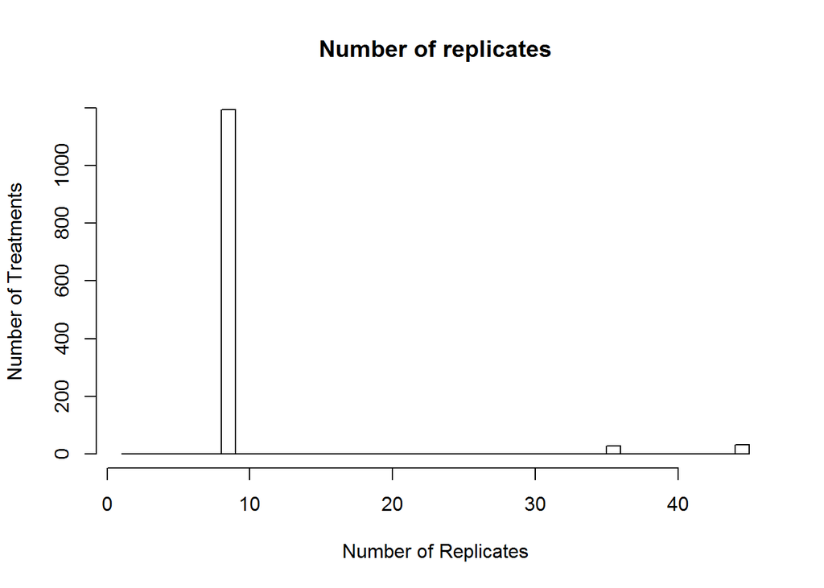

```r
n <- datp[WELLTYPE_CODE == 'SAMPLE', n[1], by = Treatment]$V1
hist(n, main = 'Number of replicates', xlab = 'Number of Replicates', ylab = 'Number of Treatments', breaks = 1 : max(n))
```

```r
table(n)
```

```
## n
##    9   36   45
## 1192   28   32
```

```r
# code below assumes data.frame (not data.table)
datp <- as.data.frame(datp)
```

# Identify the feature columns and remove troublesome features

```r
cn <- names(datp)
features <- cn[grepl('^(Cell_|Cyto_|Nuc_|Ratio_|CellCount|CellConfluency)', cn, ig = TRUE)]


features <- features[!grepl('Nuc_.*_SER.*_4', features)]                    # remove texture features at scale 4 for nuclei (small region ==> NaN)
features <- features[!grepl('NearestNeighbourDist', features)]              # too many zeros
features <- features[!grepl('Cyto_NucCytoBFP_SERSpot_4.median', features)]  # too many zeros
features <- features[!grepl('Cyto_NucCytoBFP_SERSpot_2.median', features)]  # too many zeros
features <- features[!grepl('CellCount_AllDetected', features)]             # CellCount_AllDetected is redundant, CellCount_AllRetained contains the actual number of nuclei/cells in the well (after removing those touching the image borders)

# features <- features[sample(1:length(features), size = 100)] # speed-up for debugging!!!

cat('Number of features: ', length(features), '\n')
```

```
## Number of features:  461
```

# Column statistics (before normalization)

Check that there are no NA, NaN or Inf values

```r
st <- data.frame.OverviewColumnStats.2(datp)
st <- arrange(st, -n_NA_Inf_0)
browse_table(st, 'stats input_all columns')
kable(st[st$n_NA_Inf_0 > 0, ], caption = 'Column stats (all columns)')
```

Column stats (all columns)

| colnames | isNumeric | n | n_NA_Inf_0 | n_NA | n_NaN | n_Inf | n_0 | variance | CoV | mad | mean_ | median_ |
| --- | --- | --- | --- | --- | --- | --- | --- | --- | --- | --- | --- | --- |
| CONCENTRATION | TRUE | 14688 | 1512 | 0 | 0 | 0 | 1512 | 0 | 1.165031 | 1.5e-06 | 2.9e-06 | 1e-06 |

```r
st <- data.frame.OverviewColumnStats.2(datp[, features])
st <- arrange(st, -n_NA_Inf_0)
browse_table(st, 'stats input_features only')
kable(st[st$n_NA_Inf_0 > 0, ], caption = 'Column stats (features only)')
```

Table: Column stats (features only)

# Normalize cell count: % of DMSO controls

Normalized cell count as percentage of untreated controls is often useful in downstream analysis to filter out wells/compounds with almost no cells left. The percent normalized cell count feature will not be in the pheno-signature, though. Z-score normalization of all features including cell count is performed in the next step.

```r
cellcountfeatures_raw <- colnames(datp)[grepl('CellCount_AllRetained', colnames(datp))]

stopifnot(length(cellcountfeatures_raw) > 0)

datp <- normalize.percentControls(
  datp,
  groupBy             = 'BARCODE',
  WELLTYPE_CODES          = c('LC'),                          # WELLTYPE_CODE(S) of the control wells
  featureColumns      = cellcountfeatures_raw,      # columns to normalize, NULL: all numeric columns not in 'colnames.ignore'
  agg.function        = median,
  suffix              = '.prctCntr',
  colnames.ignore     = NULL
)
```

# Normalize all features: z-score relative to DMSO controls

```r
datp <- normalize.zscoreControls_plateMean_globalPooledStdev(
  datp,
  groupBy                       = c('expID'),                   # these groups will be handled completely independently
  groupBy.mean            = c('BARCODE'),               # grouping for means (or medians)
  groupBy.pooled_sd           = NULL,                           # grouping for s.d. (or mad), pool the s.d. (or mad) into one value, NULL: across all plates
  WELLTYPE_CODES                = c('LC'),                  # WELLTYPE_CODE(S) of the control wells
  featureColumns          = features,                   # columns to normalize, NULL: all numeric columns not in 'colnames.ignore'
  suffix                  = '.zGSLC',
  centerBeforeComputingSD = TRUE,                             # TRUE: subtract within each "groupBy.mean"-group the mean (or median), then compute s.d. // FALSE: compute s.d. on non-centered data
  robust                  = FALSE,                  # FALSE: mean / sd, TRUE: median / mad
  colnames.ignore           = NULL
)
features_norm <- attr(datp, 'features.normalized')

# drop raw features from data frame, except cell count feature
features_raw_drop <- features[!grepl('CellCount_AllRetained', features)]
datp <- datp[, setdiff(names(datp), features_raw_drop)]

cat(paste0(sort(features_norm), collapse = '\n'))
```

# Column statistics (after normalization)

Check that there are no NA, NaN or Inf values

```r
st <- data.frame.OverviewColumnStats.2(datp[, features_norm])
st <- arrange(st, -n_NA_Inf_0)
browse_table(st, 'stats after normalization_features only')
kable(st[st$n_NA_Inf_0 > 0, ], caption = 'Column stats after normalization (features only)')
```

Table: Column stats after normalization (features only)

# Feature Selection

Many features in a typical imaging dataset are redundant or noisy. Using a modified version of the mRMR algorithm, we identify a subset of features with low pairwise correlation and high reproducibilty among replicates (i.e., low intra-class variability and high inter-class variability, where the class is the treatment id). In essence, this approach aims to identify a feature subset that separates pairs of replicates (high correlation between pheno-signatures) from pairs of non-replicates (low correlation between pheno-signatures) as well as possible.

mRMR first selects a constant pre-defined number of features (`nFeatures`). From this initial selection an ‘optimal’ number of features (`optN`) is selected such that the first `optN` features maximize the separation of replicates from non-replicates within 1 standard error of the optimization criterion, which is the AUC obtained from separating the the two distributions ‘correlation between replicates’ and ‘correlation between non-replicates’ by thresholding.

```r
source('PhenoPrint/MasterThesis2017/featureSelection_mRMR.R')
```

```r
columnReplicateID   <- "Treatment"  # the column that contains the replicate information; all rows with the same value are considered replicates
cellcount_ft            <- 'CellCount_AllRetained'
min_cellcount       <- 100
nFeatures               <- 75   # number of features to select (initially, the optimal number which is usually less than nFeatures will be determined below)
N_REPLICATES            <- 0    # > 0: randomly sample n replicates per treatment (to reduce influence of compounds with large number of replicates)

AUCeval.m <- 10
AUCeval.nPairsReplicates <- 0.2
AUCeval.nPairsNonReplicates <- 0.2
AUCeval.nPairsReplicatesMax <- 10000
AUCeval.nPairsNonReplicatesMax <- 10000
AUCeval.distMethod <- "pearson"
AUCeval.nThresholdsAUC <- 100

DIR_OUT <- 'C:/TEMP'

# -------------------------------
#  specify the control value
# -------------------------------
valueControl <- unique(datp[datp$WELLTYPE_CODE == 'LC', columnReplicateID])
stopifnot(length(valueControl) == 1)

# ----------
#  run mRMR
# ----------
FSres <- run_mRMR(
  dataset = datp,
  features = features_norm,    # all features to select from
  nFeatures = nFeatures,            # number of features to be selected
  min_cellcount = min_cellcount,        # select features based on wells with at least this many cells
  cellcount_ft = cellcount_ft,
  n_replicates = N_REPLICATES,      # > 0: randomly sample n replicates per treatment (to reduce influence of compounds with large number of replicates)
  columnReplicateID = columnReplicateID,
  valueControl = valueControl,
  AUCeval.m = AUCeval.m,
  AUCeval.nPairsReplicates = AUCeval.nPairsReplicates,
  AUCeval.nPairsNonReplicates = AUCeval.nPairsNonReplicates,
  AUCeval.nPairsReplicatesMax = AUCeval.nPairsReplicatesMax,
  AUCeval.nPairsNonReplicatesMax = AUCeval.nPairsNonReplicatesMax,
  AUCeval.distMethod = AUCeval.distMethod,
  AUCeval.nThresholdsAUC = AUCeval.nThresholdsAUC,
  DIR_OUT = DIR_OUT
)
```

```
## Selection of active compounds in progress...
```

```
## Finding active Ids in progress...
```

```
## Active Ids found...
```

```
## MRMR method computation ...
```

```
## Computation of the between and within variances
```

```r
features_norm_sel <- FSres$selectedFeatures[1:FSres$optN] # select the 'optimal' number of features
```

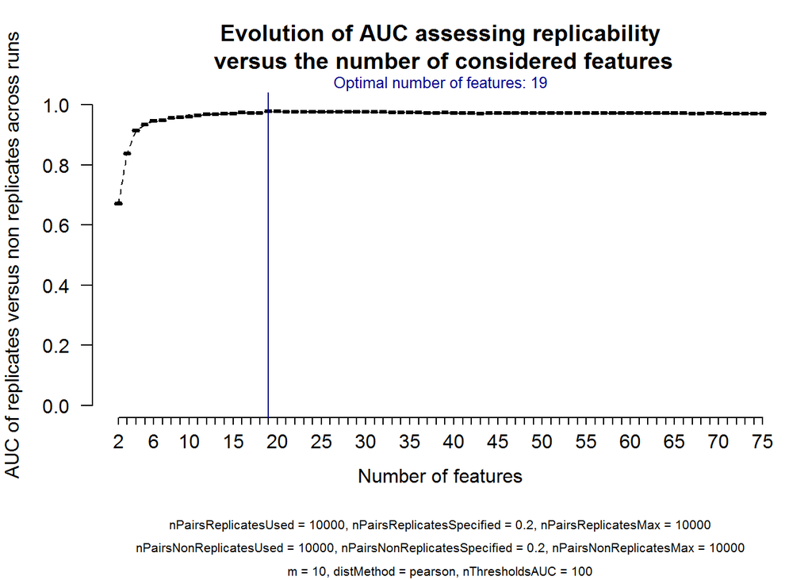

```r
plot(x = FSres$optimalNFeatAUCPearson) #AUC plot
```

The final feature set that makes up the pheno-signature of each sample is saved in the character vector `features_norm_sel`.

```r
kable(data.frame(Rank = 1 : length(features_norm_sel), Feature = features_norm_sel))
```

| Rank | Feature |
| --- | --- |
| 1 | Nuc_NucCytoBFP2GFP_PearsonCor.mean.zGSLC |
| 2 | Cell_NucCytoBFP_SERHole_1.mean.zGSLC |
| 3 | Nuc_ShapeSize_Area.mean.zGSLC |
| 4 | Nuc_RFP_SERValley_1.mean.zGSLC |
| 5 | Cell_NucCytoBFP_SERSaddle_4.mean.zGSLC |
| 6 | Nuc_RFP_SERSaddle_1.mean.zGSLC |
| 7 | Cell_NucCytoBFP_SERSaddle_1.mean.zGSLC |
| 8 | Cyto_GFP_StdInt.mean.zGSLC |
| 9 | Cell_RFP_SERHole_1.mean.zGSLC |
| 10 | Cyto_GFP_TotalInt.mean.zGSLC |
| 11 | Nuc_GFP2RFP_PearsonCor.mean.zGSLC |
| 12 | Cyto_NucCytoBFP_StdIntBC.mean.zGSLC |
| 13 | Cell_GFP_StdInt.mean.zGSLC |
| 14 | Cell_RFP_SERSaddle_4.mean.zGSLC |
| 15 | Cyto_RFP_SERSpot_4.mean.zGSLC |
| 16 | Cell_RFP_LogMeanInt.mean.zGSLC |
| 17 | Cell_GFP_SERRidge_1.mean.zGSLC |
| 18 | Cell_NucCytoBFP_SERValley_4.mean.zGSLC |
| 19 | Nuc_NucCytoBFP_SERHole_2.mean.zGSLC |

# In/active calling

Treatments that don’t show a significant difference to DMSO controls are flagged as inactive. This information can be used in downstream analysis to work with only the active treatments where appropriate.

```r
stopifnot(!any(is.na(datp$Treatment)))

source('PhenoPrint/MasterThesis2017/active_calling.R')
datp <- active_calling(datp, features_norm_sel, active_distance_percentile = 0.95)
```

```
## % active treatments:  56.42458
```

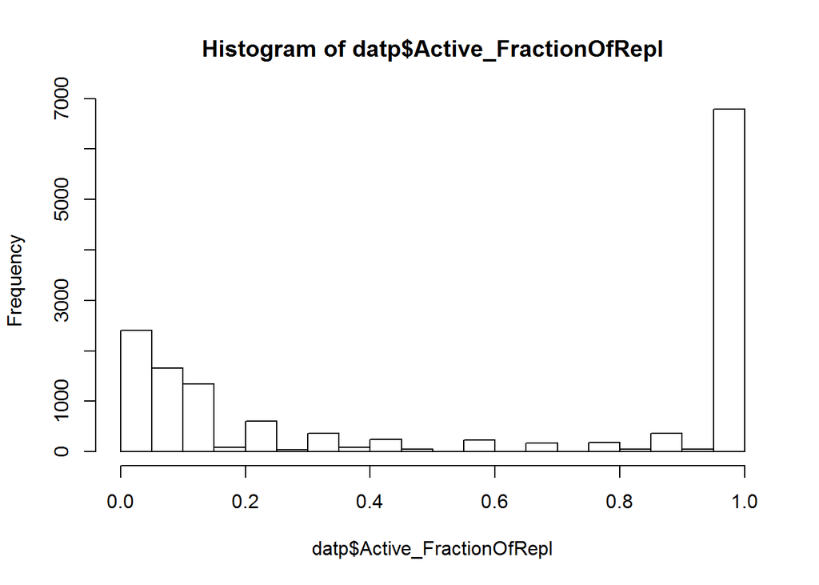

```r
hist(datp$Active_FractionOfRepl) # treatments with >= 50% active replicates are considered active
```

```r
stopifnot(!any(is.na(datp$Treatment)))
```

We now have a new colum `Active_FractionOfRepl`, the fraction of replicates of a treatment that are active, i.e., further away in terms of Euclidean distance from the mean DMSO control than the 95-percentile of individual DMSO controls are away from the mean DMSO control. We consider a treatment (with all its replicates!) active if >= 50% of its replicates are active (i.e., `Active_FractionOfRepl` >= 0.5).

# Save preprocessed data with selected features to file

```r
attr(datp, 'features')           <- features_norm
attr(datp, 'features_mRMR_all')  <- FSres$selectedFeatures
attr(datp, 'features_mRMR_optN') <- features_norm_sel

save(datp, file = fn_out)
cat('written to ',fn_out,'\n')
```

```
## written to  C:/sjaensch/docu/HCS projects/2014-09 ITS Proposal -- PhenoPrinting/MasterThesis 2017/data/p1601xxPPS_means_preprocessed.Rdata
```